# DataCollection

Leo Kitchell

11/19/2021

## Purpose

The purpose of this document is to gather data from different sources for my senior thesis. This includes pulling ACS 5 Year data from the census using their API, combining the data from InsideAirbnb, and compiling all other data needed to create my measure of gentrification

# Airbnb Data

Data has been downloaded from InsideAirbnb for 28 US cities. These data are composed of 3 files for each city. The first file includes every listing within the metropolitan area, a second file contains every review for each listing, and the third contains a forward looking calendar showing the listing’s available nights and the price for each night.

## Stacking Data

Using rbind to stack airbnb data from each filetype (Listings, Calendar, and Reviews) into three dataframes.

## Cleaning Airbnb Review Words

# Gentrification Data

The specification of gentrification which will be used in this project is heavily inspired by the work of Freeman (2005) and Bates (2013). To compose our gentrification measure we will use Census tract level data on median household income, educational attainment, and percentage of income spent on rent. **The rent measure may have to be changed to dollar amount spent on rent so that we don’t get confonding from increased household income in the tract**

## Geocoding Airbnb Listings

Mapping latitude to blocks and tracts. Predicted to take ~200 minutes per vintage.

## Census Data

### Setup Census API key to pull data.

[output not shown]

### Census Variables

Descriptions and codes of variables available in the ACS 5 year dataset located here: https://www.socialexplorer.com/data/ACS2019_5yr/metadata/?ds=ACS19_5yr

### Pulling Data from Census API

Compiling Census Data for all tracts within the States included in the AirBnB data

### Selecting MSAs

Filtering censusData to tracts contained within MSAs.

## Creating Education Variable, Renaming Gentrification Variables to be Informative

[output not shown]

[output not shown]

[output not shown]

## Calculating Gentrification Index by Tract

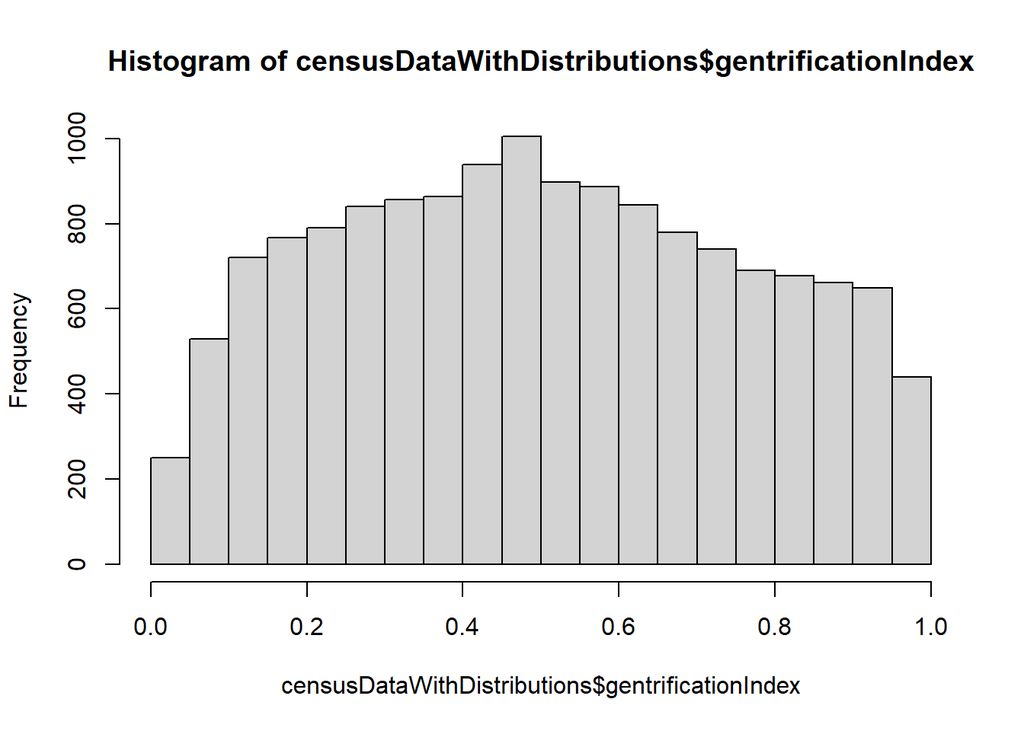

## Pulling Geometries to Map

## Mapping Gentrification Index by MSA

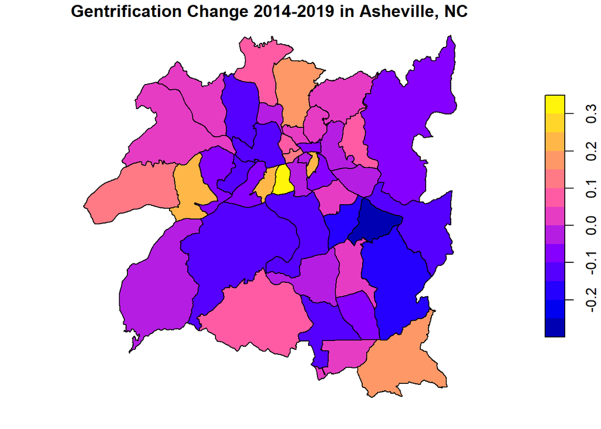

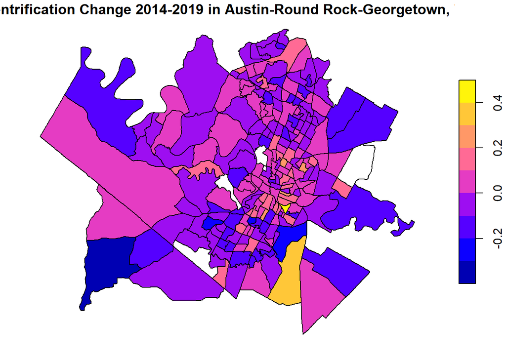

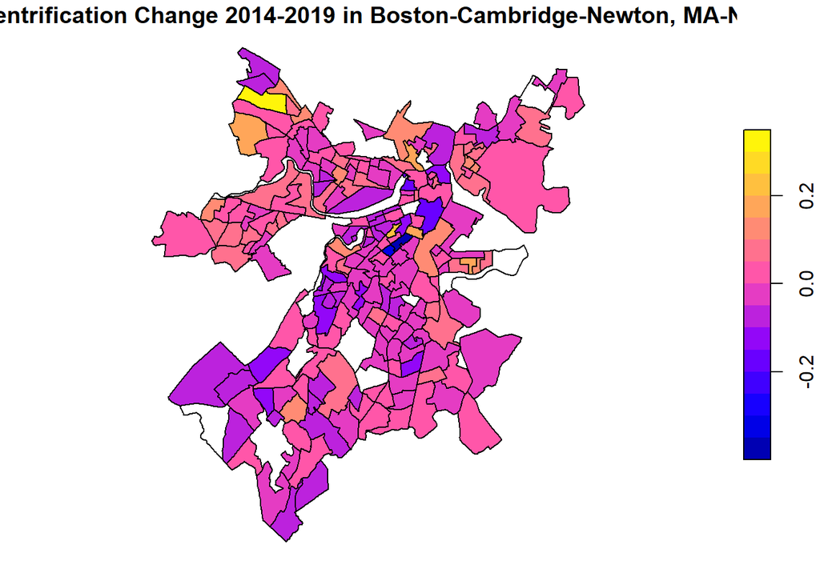

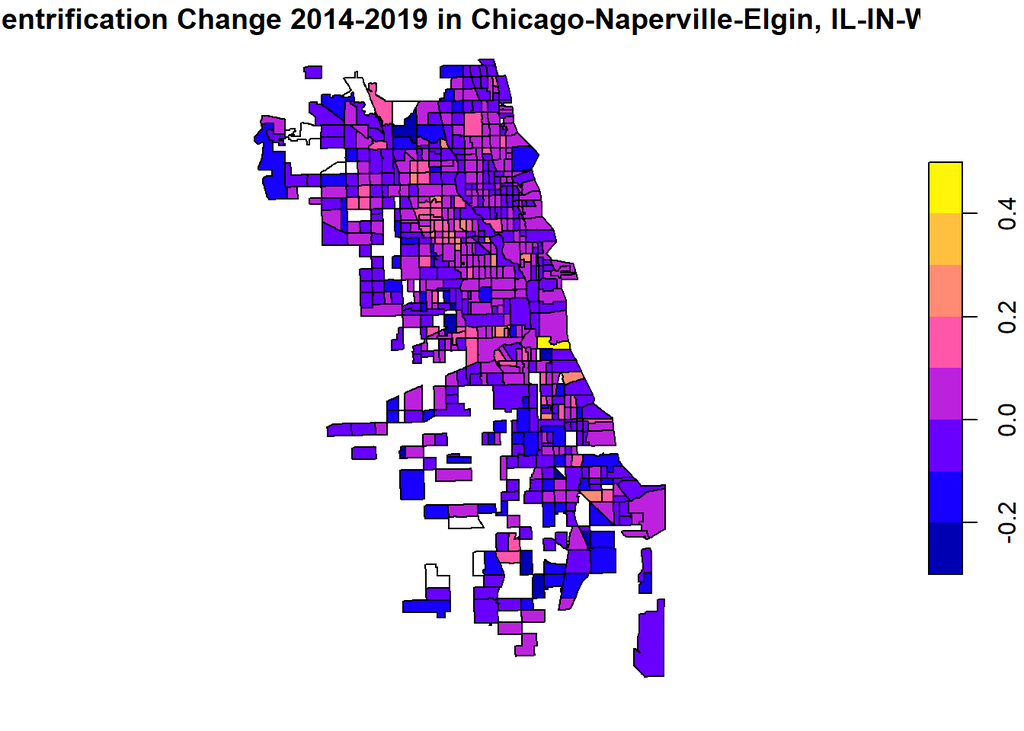

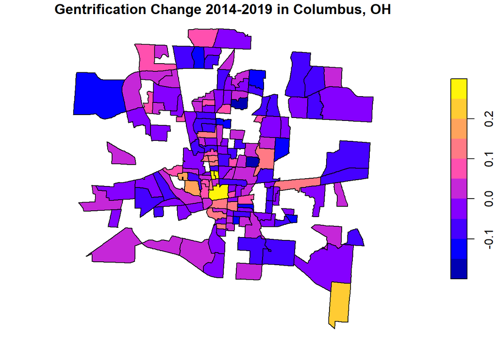

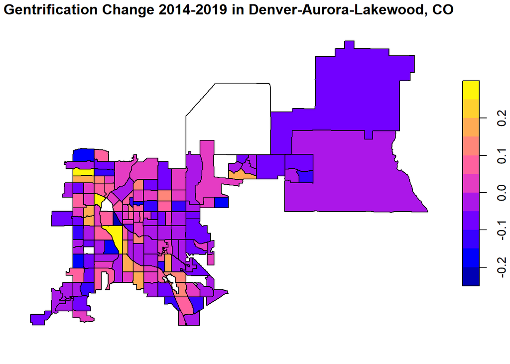

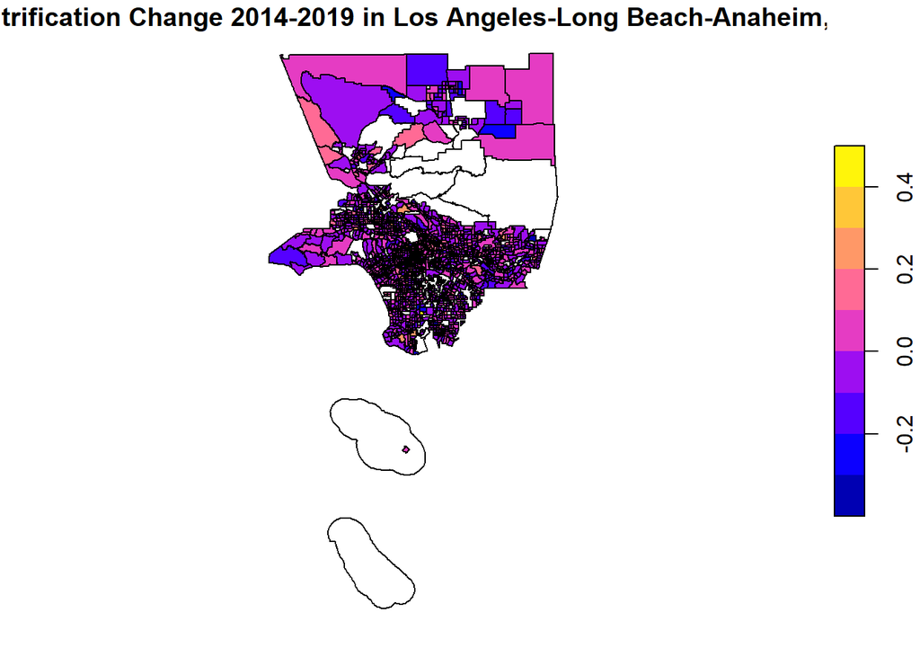

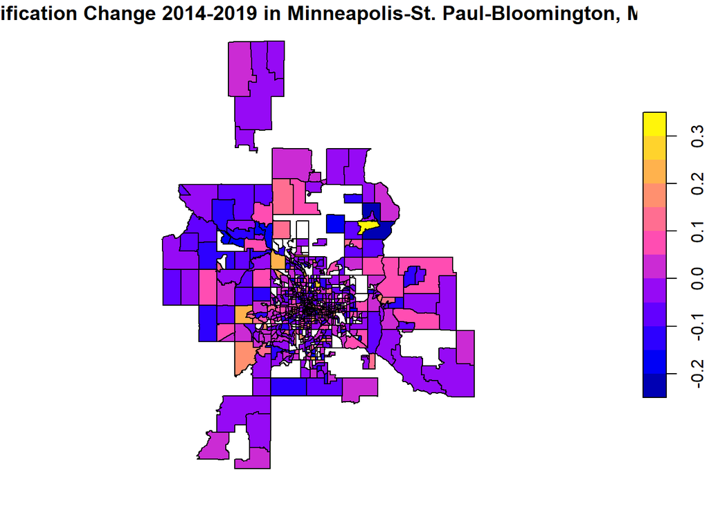

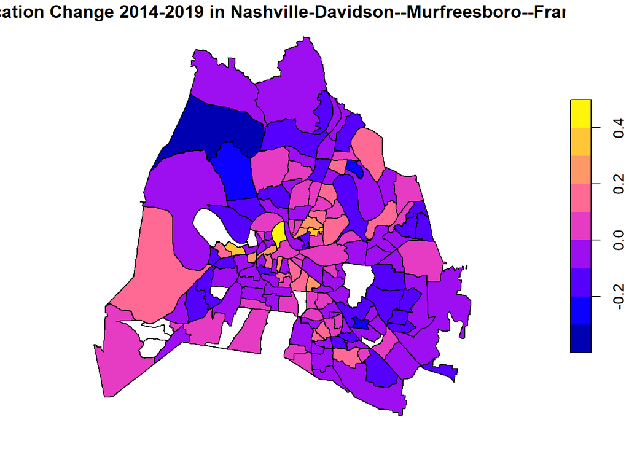

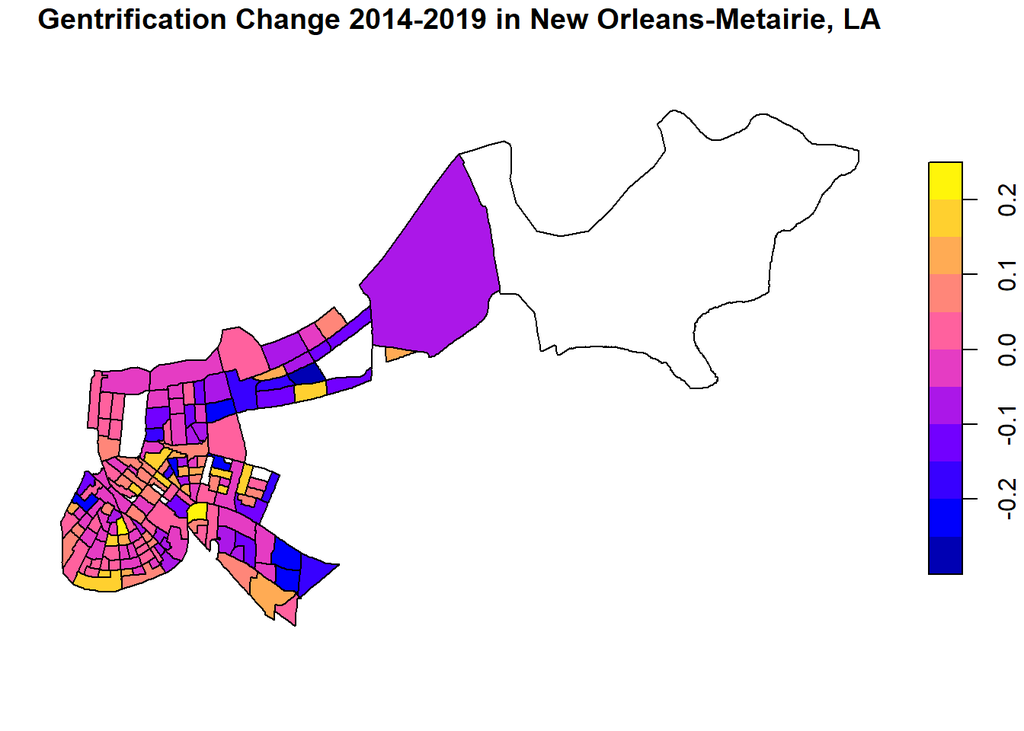

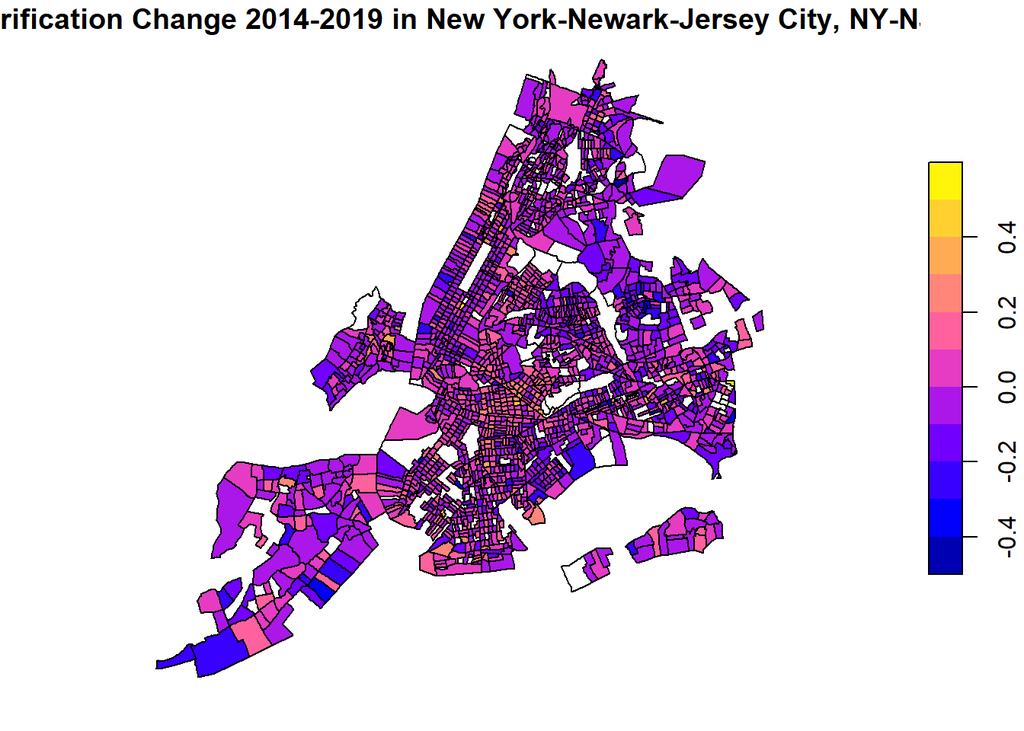

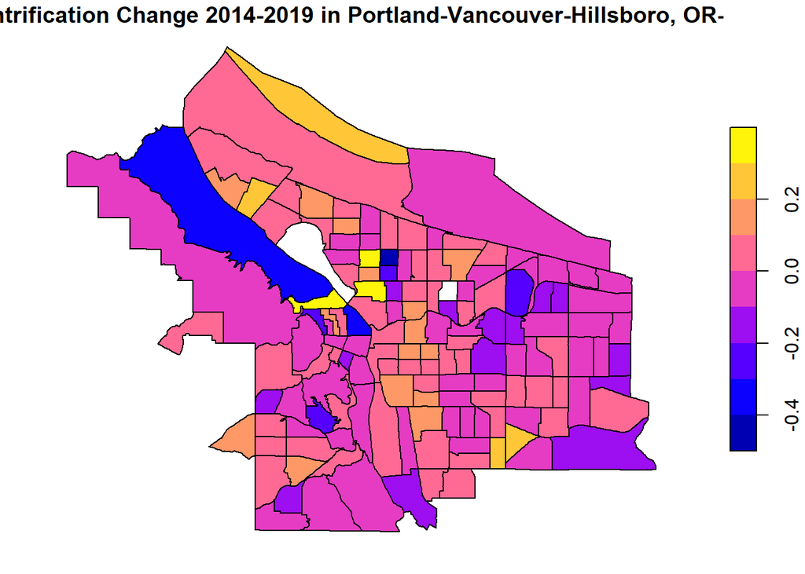

[7 more figures not shown]

## Interactive Maps - Unfinished

### Identifying tracts which changed between 2000 and 2010

Not necessary for current process

```
##
##         60014 60019 60371 60372 60373 60374 60375 60376 60377 60378 60379 60530
##   06001  1957     3     0     0     0     0     0     0     0     0     0     0
##   06037     0     0  8367  9602  1025  3946  2489  2329  3127   870   665     0
##   06053     0     0     0     0     0     0     0     0     0     0     0   185
##   06071     0     0     0     0     0     0     0     0     0     0     0     0
##   06073     0     0     0     0     0     0     0     0     0     0     0     0
##   06075     0     0     0     0     0     0     0     0     0     0     0     0
##   08001     0     0     0     0     0     0     0     0     0     0     0     0
##   08005     0     0     0     0     0     0     0     0     0     0     0     0
##   08031     0     0     0     0     0     0     0     0     0     0     0     0
##   08059     0     0     0     0     0     0     0     0     0     0     0     0
##
##         60710 60730 60750 60759 80010 80019 80050 80310 80319 80590
##   06001     0     0     0     0     0     0     0     0     0     0
##   06037     0     0     0     0     0     0     0     0     0     0
##   06053     0     0     0     0     0     0     0     0     0     0
##   06071     1     0     0     0     0     0     0     0     0     0
##   06073     0  9669     0     0     0     0     0     0     0     0
##   06075     0     0  6531    35     0     0     0     0     0     0
##   08001     0     0     0     0     9     1     0     0     0     0
##   08005     0     0     0     0     0     0    21     0     0     0
##   08031     0     0     0     0     0     0     0  3808     7     0
##   08059     0     0     0     0     0     0     0     0     0     4
```

# Homework

Have gentrification method for each block map and look at what the gentrification distribution looks like by Friday. Have mapped for 5 cities. IF possible have for 28 cities. Push to github.

Think about the X variables. Airbnb review data, airbnb text data, number of airbnbs, population.

Restrict review data to be within the range 2015-2019.